# Comparison of Supervised Machine Learning Estimators: LCIA QSAR Project

**Date:** April 6, 2023

Building on the advice of Profs. Fred Wright and Weishueh Chiu, this notebook compares the performances of a suite of candidate estimators in predicting the continuous log10(POD) for a subset of chemicals as part of the LCIA QSAR Project. The term, `estimator` is used herein to refer to a particular type of machine learning algorithm (e.g., Random Forest), whereas `model` refers to a specific implementation of an estimator when given a dataset for training. In other words, one estimator can correspond to several models.

### Overview

1. Load and visualize the data
2. Feature preprocessing
3. Estimator comparison
4. Potential next steps

```python
import pandas as pd
import numpy as np
from os import path
import matplotlib.pyplot as plt

from sklearn.impute import SimpleImputer
from sklearn.linear_model import (
    Ridge,
    Lasso
)
from sklearn.ensemble import (
    RandomForestRegressor,
    GradientBoostingRegressor
)
from xgboost import XGBRegressor
from sklearn.pipeline import Pipeline
from sklearn import metrics
from sklearn.inspection import permutation_importance

import parse
# Enable modules to be imported from the parent directory.
import sys
sys.path.append('..')
from common.transform import (
    BasicFeatureSelector,
    Log10Transformer,
    SelectiveScaler
)
from common import (
    features,
    learn,
    plot
)
```

## Load the data

### Target variable: log10(POD) for non-reproductive, non-developmental effects

```python
effect_type = 'non-reproductive/developmental effects'
exposure_route = 'oral'
target_variable = 'POD [mg/kg-d]'

log10_pods = (
    pd.read_csv(
        path.join('Input', 'log10-points-of-departure.csv'),
        index_col=0)
    [effect_type]
    .dropna())

log10_pods
```

```
DTXSID
DTXSID5020281                              -1.098677
DTXSID8020961                              -0.231734
DTXSID7030698                               3.472003
DTXSID2026652                               1.042817
DTXSID6026080                               1.842616
                                              ...
NODTXSID_NOCAS_Vanadium carbide nitride    -0.187338
NODTXSID_NOCAS_vanadyl pyrophosphate        1.551173
NODTXSID_NOCAS_Vinasses, residue of ferm    3.107675
NODTXSID_NOCAS_Yellow pigment additive      1.305606
NODTXSID_NOCAS_Zeolite, cuboidal, crysta    2.019939
Name: non-reproductive/developmental effects, Length: 2024, dtype: float64
```

### Features: Combined OPERA+TEST predictions

Presently, using only those features that are readily available through CompTox. Still awaiting approval from Help Desk to install OPERA.

For some parameters, there are both OPERA and TEST values. In such cases, we used OPERA values because the applicability domain may be greater.

```python
chem_props_path = path.join(
    'Features',
    'chemical-properties.csv')

chem_properties = pd.read_csv(
    chem_props_path,
    index_col='DTXSID')

# Inverse transform log-scale columns to avoid redundancy. Assume base 10.
log_columns = [c for c in chem_properties if 'LOG' in c]
chem_properties.loc[:, log_columns] = 10**chem_properties[log_columns]

chem_properties
```

| DTXSID | AVERAGE_MASS | 48HR_DAPHNIA_LC50_MOL/L_TEST_PRED | DENSITY_G/CM^3_TEST_PRED | DEVTOX_TEST_PRED | 96HR_FATHEAD_MINNOW_MOL/L_TEST_PRED | FLASH_POINT_DEGC_TEST_PRED | AMES_MUTAGENICITY_TEST_PRED | ORAL_RAT_LD50_MOL/KG_TEST_PRED | SURFACE_TENSION_DYN/CM_TEST_PRED | THERMAL_CONDUCTIVITY_MW/(M*K)_TEST_PRED | ... | HENRYS_LAW_ATM-M3/MOLE_OPERA_PRED | OPERA_KM_DAYS_OPERA_PRED | OCTANOL_AIR_PARTITION_COEFF_LOGKOA_OPERA_PRED | SOIL_ADSORPTION_COEFFICIENT_KOC_L/KG_OPERA_PRED | OCTANOL_WATER_PARTITION_LOGP_OPERA_PRED | MELTING_POINT_DEGC_OPERA_PRED | OPERA_PKAA_OPERA_PRED | OPERA_PKAB_OPERA_PRED | VAPOR_PRESSURE_MMHG_OPERA_PRED | WATER_SOLUBILITY_MOL/L_OPERA_PRED |
| --- | --- | --- | --- | --- | --- | --- | --- | --- | --- | --- | --- | --- | --- | --- | --- | --- | --- | --- | --- | --- | --- |
| DTXSID5020281 | 157.550 | 1.081430e-04 | 1.372 | 0.323 | 5.714790e-05 | 109.227 | 0.966 | 0.007079 | NaN | 137.950 | ... | 4.947790e-06 | 0.332365 | 2.124320e+04 | 507.6930 | 246.342872 | 82.9942 | NaN | NaN | 2.203470e-02 | 1.317610e-03 |
| DTXSID8020961 | 138.126 | 6.486340e-05 | 1.309 | 0.250 | 4.385310e-04 | 141.229 | 0.642 | 0.009141 | NaN | 162.043 | ... | 1.265030e-09 | 0.306715 | 3.734737e+06 | 75.9962 | 24.436556 | 145.5400 | NaN | 1.03 | 3.265100e-06 | 4.815930e-03 |
| DTXSID0021834 | 139.110 | 5.395110e-05 | 1.376 | 0.281 | 1.472310e-04 | 117.588 | 0.490 | 0.005140 | NaN | 152.108 | ... | 4.207650e-10 | 0.251436 | 1.297807e+06 | 233.1200 | 81.678923 | 113.5640 | 7.13 | NaN | 9.970590e-05 | 9.679290e-02 |
| DTXSID3032622 | 99.089 | NaN | 1.276 | 0.639 | NaN | 36.844 | 0.372 | 0.004457 | NaN | 155.108 | ... | 9.095360e-08 | 0.288388 | 5.393492e+04 | 10.0605 | 2.852542 | 86.5110 | NaN | NaN | 1.396390e-03 | 8.066960e-01 |
| DTXSID2044347 | 150.177 | 1.312200e-04 | 1.072 | 0.621 | 2.904020e-04 | 98.358 | 0.305 | 0.004887 | 36.672 | 139.705 | ... | 9.683370e-08 | 0.279812 | 1.183477e+05 | 98.5113 | 55.324819 | 37.4772 | NaN | NaN | 6.500820e-03 | 1.201570e-02 |
| ... | ... | ... | ... | ... | ... | ... | ... | ... | ... | ... | ... | ... | ... | ... | ... | ... | ... | ... | ... | ... | ... |
| DTXSID5057882 | 300.150 | 2.065380e-07 | 1.363 | 0.679 | 7.211070e-07 | 187.442 | 0.313 | NaN | NaN | 138.484 | ... | 2.333810e-07 | 3.627750 | 4.228633e+10 | 8156.8700 | 7006.481829 | 161.2890 | NaN | NaN | 2.468280e-07 | 1.982760e-06 |
| DTXSID5057884 | 409.310 | NaN | 1.434 | 0.933 | NaN | 297.064 | 0.200 | NaN | NaN | NaN | ... | 1.494930e-10 | 0.148214 | 3.513581e+09 | 2186.0300 | 808.946872 | 181.9450 | NaN | NaN | 1.335850e-09 | 3.015700e-05 |
| DTXSID0057885 | 481.519 | 8.035260e-06 | 1.289 | 1.027 | 1.009250e-07 | 324.706 | 0.049 | NaN | NaN | NaN | ... | 6.479200e-10 | 1.686170 | 4.748320e+09 | 161483.0000 | 309592.192625 | 168.4210 | NaN | NaN | 2.338530e-09 | 3.245060e-08 |
| DTXSID1057905 | NaN | NaN | NaN | NaN | NaN | NaN | NaN | NaN | NaN | NaN | ... | NaN | NaN | NaN | NaN | NaN | NaN | NaN | NaN | NaN | NaN |
| DTXSID6057906 | 532.670 | NaN | NaN | NaN | NaN | NaN | NaN | NaN | NaN | NaN | ... | NaN | NaN | NaN | NaN | NaN | NaN | NaN | NaN | NaN | NaN |

6598 rows × 26 columns

```python
log10_pods, chem_properties = features.with_common_index([log10_pods, chem_properties])
X, y = chem_properties.copy().to_numpy(), log10_pods.copy().to_numpy()

print(f'{y.shape[0]} chemicals for modeling')
```

```
1634 chemicals for modeling
```

## Visualize the data before preprocessing

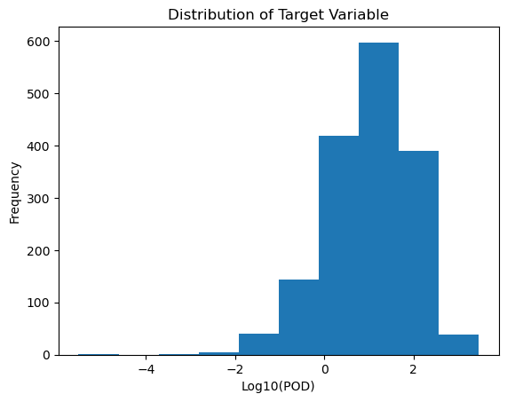

```python
fig, ax = plt.subplots()
_ = pd.Series(y).plot.hist(ax=ax)
_ = ax.set_xlabel('Log10(POD)')
_ = ax.set_title('Distribution of Target Variable')
```

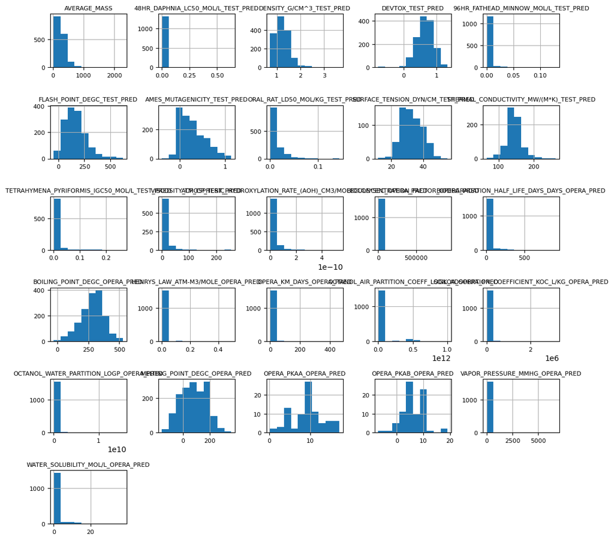

```python
_ = plot.histograms_for_columns(
    chem_properties,
    figsize=(10., 10.))
```

## Overview of feature engineering pipeline (full dataset)

All features are continuous but different scales and some are skewed. We will engineer all features using a consistent preprocessing pipeline:

1. **Feature selection:** Drop features that meet any of the following conditions:
   - Low variance (constant)
   - Sparse: Percentage of missing values exceeding some threshold
   - Highly correlated
1. **Transform:** Apply log10-transformation to features that are postive and not significantly left-skewed.
1. **Impute missing values:** Use the median.
1. **Center and scale:** Standardize and scale to unit variance with median and MAD.

```python
print(f'{len(chem_properties.columns)} features before preprocessing')

print('Proportion of missing values:')
(chem_properties.isna().sum() / len(chem_properties)).sort_values(ascending=False).round(2)
```

```
26 features before preprocessing
Proportion of missing values:
```

```
OPERA_PKAB_OPERA_PRED                                               0.95
OPERA_PKAA_OPERA_PRED                                               0.95
SURFACE_TENSION_DYN/CM_TEST_PRED                                    0.62
THERMAL_CONDUCTIVITY_MW/(M*K)_TEST_PRED                             0.54
VISCOSITY_CP_CP_TEST_PRED                                           0.53
TETRAHYMENA_PYRIFORMIS_IGC50_MOL/L_TEST_PRED                        0.47
96HR_FATHEAD_MINNOW_MOL/L_TEST_PRED                                 0.25
ORAL_RAT_LD50_MOL/KG_TEST_PRED                                      0.22
48HR_DAPHNIA_LC50_MOL/L_TEST_PRED                                   0.20
AMES_MUTAGENICITY_TEST_PRED                                         0.16
DEVTOX_TEST_PRED                                                    0.14
FLASH_POINT_DEGC_TEST_PRED                                          0.11
DENSITY_G/CM^3_TEST_PRED                                            0.11
SOIL_ADSORPTION_COEFFICIENT_KOC_L/KG_OPERA_PRED                     0.05
BIODEGRADATION_HALF_LIFE_DAYS_DAYS_OPERA_PRED                       0.04
BIOCONCENTRATION_FACTOR_OPERA_PRED                                  0.04
OCTANOL_WATER_PARTITION_LOGP_OPERA_PRED                             0.04
WATER_SOLUBILITY_MOL/L_OPERA_PRED                                   0.04
OPERA_KM_DAYS_OPERA_PRED                                            0.04
HENRYS_LAW_ATM-M3/MOLE_OPERA_PRED                                   0.04
ATMOSPHERIC_HYDROXYLATION_RATE_(AOH)_CM3/MOLECULE*SEC_OPERA_PRED    0.04
OCTANOL_AIR_PARTITION_COEFF_LOGKOA_OPERA_PRED                       0.04
MELTING_POINT_DEGC_OPERA_PRED                                       0.04
BOILING_POINT_DEGC_OPERA_PRED                                       0.04
VAPOR_PRESSURE_MMHG_OPERA_PRED                                      0.04
AVERAGE_MASS                                                        0.00
dtype: float64
```

These preprocessing steps are now compatible with the scikit-learn API, which enables hyperparameter tuning, etc. The following hyperparameter values will be used in this demonstration.

```python
selector = (
    BasicFeatureSelector(
        thres_missing=0.25,  # threshold proportion missing
        thres_corr=0.9,  # threshold correlation coefficient
        method_corr='pearson')  # method
    .set_output(transform='pandas')
)

transformer = (
    Log10Transformer(
        alpha=0.05)  # significance level for skew test
    .set_output(transform='pandas')
)

imputer = (
    SimpleImputer(strategy='median')
    .set_output(transform='pandas')
)

scaler = (
    SelectiveScaler(
        measure='median')
    .set_output(transform='pandas')
)

preprocessing_pipe = [
    selector,
    transformer,
    imputer,
    scaler
]
```

### Visualize the resulting features after preprocessing

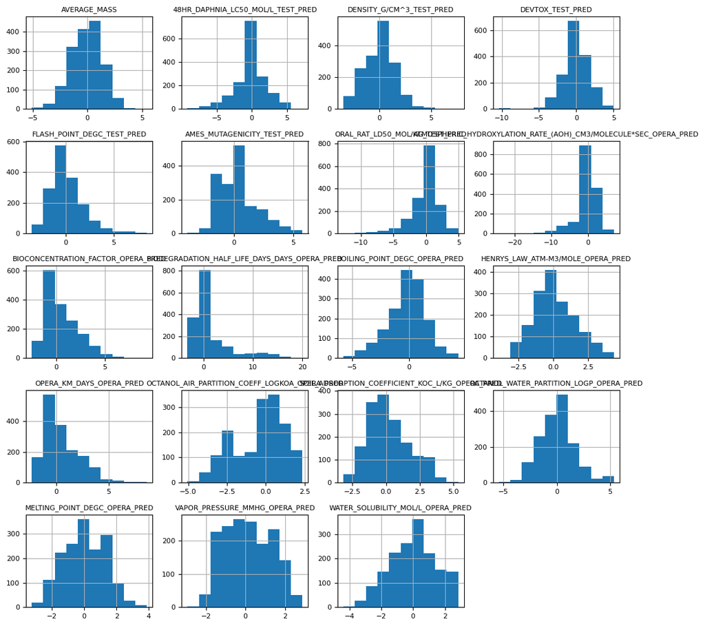

```python
chem_properties_trans = chem_properties
for step in preprocessing_pipe:
    chem_properties_trans = step.fit_transform(chem_properties_trans)

_ = plot.histograms_for_columns(
    chem_properties_trans,
    figsize=(10., 10.))
```

```python
selector.low_variance_features_
```

```
[]
```

```python
selector.sparse_features_
```

```
['96HR_FATHEAD_MINNOW_MOL/L_TEST_PRED',
 'SURFACE_TENSION_DYN/CM_TEST_PRED',
 'THERMAL_CONDUCTIVITY_MW/(M*K)_TEST_PRED',
 'TETRAHYMENA_PYRIFORMIS_IGC50_MOL/L_TEST_PRED',
 'VISCOSITY_CP_CP_TEST_PRED',
 'OPERA_PKAA_OPERA_PRED',
 'OPERA_PKAB_OPERA_PRED']
```

```python
selector.correlated_features_
```

```
[]
```

## Estimator comparison with repeated internal cross-validation

According to Fred Wright:

```
- Typically, Random Forest, XGBoost, Lasso and Ridge regression span a good range of performance for QSAR situations

- Default hyperparameters can often provide reasonable results
```

What follows is a comparison of these estimators using a repeated internal cross-validation, 5 folds with 50 repeats. Each repeat uses a different randomization state for shuffling and splitting the data to estimate the variability in model performance across different random partitions of the same dataset. The coefficient of determination (R2) is used to compare estimator performances.

```python
rng = np.random.RandomState(seed=0)

# May not be needed.
fit_params = {}

metrics_keys = learn.regression_metrics
```

```python
%%time

n_splits = 5
n_repeats = 50
random_state = 1

# Use the same rng across estimators for comparability.
estimators = {
    'Ridge': Ridge(random_state=rng),
    'Lasso': Lasso(random_state=rng),
    'Random_Forest': RandomForestRegressor(random_state=rng, n_jobs=-1),
    'Gradient_Boost': GradientBoostingRegressor(random_state=rng),
    'XGBoost': XGBRegressor(random_state=rng, n_jobs=-1)
}

preprocessing_steps = [
    ('selector', selector),
    ('transformer', transformer),
    ('imputer', imputer),
    ('scaler', scaler),
]

# Inialize a container.
cv_results = {}
for k, est in estimators.items():

    pipe = Pipeline(steps=preprocessing_steps + [('estimator', est)])

    cv_results[k] = learn.repeated_kfold(
        pipe,
        X,
        y,
        metrics_keys,
        n_splits=n_splits,
        n_repeats=n_repeats,
        random_state=random_state,
        **fit_params)

cv_results = pd.concat(cv_results, axis=1)

cv_results
```

```
CPU times: total: 33min 2s
Wall time: 7min 22s
```

|  | Ridge explained_variance_score | Ridge max_error | Ridge mean_absolute_error | Ridge mean_squared_error | Ridge median_absolute_error | Ridge mean_absolute_percentage_error | Ridge mean_pinball_loss | Ridge r2_score | Ridge mean_tweedie_deviance | Ridge d2_tweedie_score | ... | XGBoost explained_variance_score | XGBoost max_error | XGBoost mean_absolute_error | XGBoost mean_squared_error | XGBoost median_absolute_error | XGBoost mean_absolute_percentage_error | XGBoost mean_pinball_loss | XGBoost r2_score | XGBoost mean_tweedie_deviance | XGBoost d2_tweedie_score |
| --- | --- | --- | --- | --- | --- | --- | --- | --- | --- | --- | --- | --- | --- | --- | --- | --- | --- | --- | --- | --- | --- |
| 0 | 0.335925 | 3.797388 | 0.623179 | 0.650532 | 0.505027 | 2.416904 | 0.311589 | 0.335916 | 0.650532 | 0.335916 | ... | 0.353692 | 2.680847 | 0.615892 | 0.634990 | 0.483451 | 2.628512 | 0.307946 | 0.351781 | 0.634990 | 0.351781 |
| 1 | 0.422056 | 3.809536 | 0.619468 | 0.637097 | 0.514603 | 1.790843 | 0.309734 | 0.414065 | 0.637097 | 0.414065 | ... | 0.382401 | 4.323492 | 0.606705 | 0.683606 | 0.496363 | 1.426003 | 0.303353 | 0.371291 | 0.683606 | 0.371291 |
| 2 | 0.264274 | 4.906508 | 0.637004 | 0.726911 | 0.488746 | 12.960183 | 0.318502 | 0.264224 | 0.726911 | 0.264224 | ... | 0.251265 | 3.703556 | 0.637940 | 0.740387 | 0.465279 | 16.770743 | 0.318970 | 0.250584 | 0.740387 | 0.250584 |
| 3 | 0.300386 | 2.982130 | 0.603783 | 0.612075 | 0.511299 | 2.297918 | 0.301892 | 0.296265 | 0.612075 | 0.296265 | ... | 0.288484 | 2.576804 | 0.595702 | 0.618855 | 0.456742 | 1.758976 | 0.297851 | 0.288469 | 0.618855 | 0.288469 |
| 4 | 0.164053 | 3.875562 | 0.603696 | 0.608551 | 0.490543 | 1.224681 | 0.301848 | 0.162037 | 0.608551 | 0.162037 | ... | 0.148062 | 3.361344 | 0.586090 | 0.620724 | 0.423069 | 1.206650 | 0.293045 | 0.145276 | 0.620724 | 0.145276 |
| ... | ... | ... | ... | ... | ... | ... | ... | ... | ... | ... | ... | ... | ... | ... | ... | ... | ... | ... | ... | ... | ... |
| 245 | 0.331566 | 4.751450 | 0.632052 | 0.665045 | 0.552340 | 3.007539 | 0.316026 | 0.329986 | 0.665045 | 0.329986 | ... | 0.350857 | 3.770800 | 0.601147 | 0.646637 | 0.470634 | 2.527082 | 0.300574 | 0.348531 | 0.646637 | 0.348531 |
| 246 | 0.339565 | 2.901574 | 0.574437 | 0.566338 | 0.455283 | 2.027570 | 0.287218 | 0.339137 | 0.566338 | 0.339137 | ... | 0.315347 | 2.290439 | 0.598894 | 0.589158 | 0.496939 | 1.837660 | 0.299447 | 0.312508 | 0.589158 | 0.312508 |
| 247 | 0.344176 | 2.724125 | 0.608138 | 0.629989 | 0.476545 | 1.931279 | 0.304069 | 0.344075 | 0.629989 | 0.344075 | ... | 0.293582 | 3.989106 | 0.594539 | 0.680988 | 0.410172 | 1.893949 | 0.297270 | 0.290977 | 0.680988 | 0.290977 |
| 248 | 0.366747 | 3.690864 | 0.605738 | 0.621815 | 0.538436 | 11.589416 | 0.302869 | 0.366704 | 0.621815 | 0.366704 | ... | 0.269685 | 5.064693 | 0.640481 | 0.717080 | 0.500591 | 13.374326 | 0.320240 | 0.269679 | 0.717080 | 0.269679 |
| 249 | 0.189973 | 3.741241 | 0.649594 | 0.705139 | 0.528983 | 1.699177 | 0.324797 | 0.189969 | 0.705139 | 0.189969 | ... | 0.232441 | 3.187292 | 0.614206 | 0.668171 | 0.479625 | 1.293498 | 0.307103 | 0.232436 | 0.668171 | 0.232436 |

250 rows × 50 columns

**NOTE:** XGBoost is a separate Python library from scikit-learn. From my understanding, XGBoost provides a more regularized version of the Gradient Boosting regressor in scikit-learn with some potential performance enhancements.

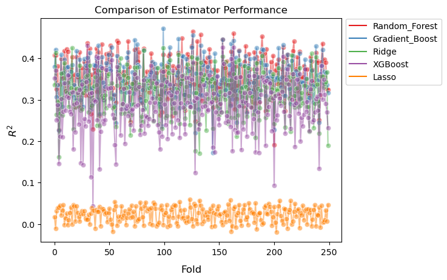

```python
model_scores = cv_results.xs('r2_score', axis=1, level=-1)

_ = plot.model_scores_by_fold(model_scores, '$R^2$', xlim=None)
```

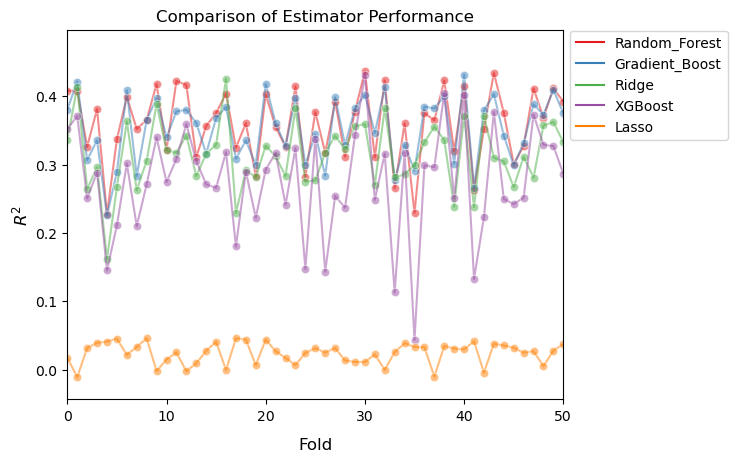

```python
_ = plot_model_scores_by_fold(model_scores, '$R^2$', xlim=(0., 50.))
```

We can observe that estimator performances co-vary depending on the fold, i.e., which subset of training data they see.

```python
model_scores.describe().round(2).drop('count')
```

|  | Ridge | Lasso | Random_Forest | Gradient_Boost | XGBoost |
| --- | --- | --- | --- | --- | --- |
| mean | 0.31 | 0.02 | 0.36 | 0.35 | 0.28 |
| std | 0.05 | 0.02 | 0.05 | 0.05 | 0.06 |
| min | 0.16 | -0.02 | 0.19 | 0.17 | 0.04 |
| 25% | 0.28 | 0.01 | 0.33 | 0.32 | 0.24 |
| 50% | 0.32 | 0.03 | 0.36 | 0.35 | 0.29 |
| 75% | 0.35 | 0.04 | 0.40 | 0.38 | 0.33 |
| max | 0.43 | 0.06 | 0.46 | 0.47 | 0.43 |

```python
model_scores.corr().round(2)
```

|  | Ridge | Lasso | Random_Forest | Gradient_Boost | XGBoost |
| --- | --- | --- | --- | --- | --- |
| Ridge | 1.00 | -0.57 | 0.67 | 0.81 | 0.59 |
| Lasso | -0.57 | 1.00 | -0.32 | -0.45 | -0.33 |
| Random_Forest | 0.67 | -0.32 | 1.00 | 0.83 | 0.82 |
| Gradient_Boost | 0.81 | -0.45 | 0.83 | 1.00 | 0.78 |
| XGBoost | 0.59 | -0.33 | 0.82 | 0.78 | 1.00 |

### What's going on with Lasso?

From my understanding, Lasso penalizes models with high variance by including the L1 norm in the cost function. The L1 norm allows feature weights to be forced to zero during Gradient Descent optimization, which essentially performs feature selection.

```python
# ... from the previous iteration.
estimators['Lasso'].coef_
```

```
array([-0.        ,  0.        , -0.        ,  0.        ,  0.        ,
       -0.        ,  0.02263109,  0.        , -0.        , -0.        ,
       -0.        , -0.        , -0.        , -0.        , -0.        ,
       -0.        ,  0.        , -0.        ,  0.        ])
```

The 'alpha' hyperparameter of the Lasso estimator could be tuned to relax the amount of regularization. This parameter is a constant that multiplies the regularization term in the cost function, such that `a = 0` --> ordinary least squares.

## Potential next steps

1. After install OPERA, run the complete set of OPERA features through this workflow
2. Hyperparameter tuning - short literature search? Probably dataset-dependent?
3. Build an ensemble or "meta-estimator" that aggregates the predictions of the top-performing estimators

### Questions

- Feature importances?
- At what point would it be advisable to leverage a HPC cluster?